# Code Along 10

Topic modeling for #TidyTuesday Spice Girls lyrics

Daniel Lee

2023-04-14

Our modeling goal is to “discover” topics in the [lyrics of Spice Girls songs](https://github.com/rfordatascience/tidytuesday/blob/master/data/2021/2021-12-14/readme.md). Instead of a supervised or predictive model where our observations have labels, this is an unsupervised approach.

https://juliasilge.com/blog/spice-girls/

```r
library(tidyverse)
library(tidytext)

lyrics <- read_csv("https://raw.githubusercontent.com/rfordatascience/tidytuesday/master/data/2021/2021-12-14/lyrics.csv")
```

## Explore data

```r
lyrics %>% distinct(album_name)
```

```
## # A tibble: 3 × 1
##   album_name
##   <chr>
## 1 Spice
## 2 Spiceworld
## 3 Forever
```

```r
lyrics %>% distinct(album_name, song_name)
```

```
## # A tibble: 31 × 2
##    album_name song_name
##    <chr>      <chr>
##  1 Spice      "Wannabe"
##  2 Spice      "Say You\x92ll Be There"
##  3 Spice      "2 Become 1"
##  4 Spice      "Love Thing"
##  5 Spice      "Last Time Lover"
##  6 Spice      "Mama"
##  7 Spice      "Who Do You Think You Are"
##  8 Spice      "Something Kinda Funny"
##  9 Spice      "Naked"
## 10 Spice      "If U Can\x92t Dance"
## # … with 21 more rows
```

```r
tidy_lyrics <-
  lyrics %>%
  mutate(song_name = str_replace_all(song_name, "\x92", "'")) %>%
  unnest_tokens(word, line) %>%
  anti_join(get_stopwords())
tidy_lyrics %>%
  count(word, sort = TRUE)
```

```
## # A tibble: 979 × 2
##    word      n
##    <chr> <int>
##  1 get     153
##  2 love    137
##  3 know    124
##  4 time    106
##  5 wanna   102
##  6 never   101
##  7 oh       88
##  8 yeah     88
##  9 la       85
## 10 got      82
## # … with 969 more rows
```

```r
tidy_lyrics %>%
  count(song_name, word, sort = TRUE)
```

```
## # A tibble: 2,206 × 3
##    song_name                       word           n
##    <chr>                           <chr>      <int>
##  1 Saturday Night Divas            get           91
##  2 Spice Up Your Life              la            64
##  3 If U Can't Dance                dance         60
##  4 Holler                          holler        48
##  5 Never Give Up on the Good Times never         47
##  6 Move Over                       generation    41
##  7 Saturday Night Divas            deeper        41
##  8 Move Over                       yeah          39
##  9 Something Kinda Funny           got           39
## 10 Never Give Up on the Good Times give          38
## # … with 2,196 more rows
```

## Train a topic model

To train a topic model with the stm package, we need to create a sparse matrix from our tidy dataframe of tokens.

```r
lyrics_sparse <-
  tidy_lyrics %>%
  count(song_name, word) %>%
  cast_sparse(song_name, word, n)

dim(lyrics_sparse)
```

```
## [1]  31 979
```

A topic model like this one models:

- each document as a mixture of topics
- each topic as a mixture of words

The most important parameter when training a topic modeling is K, the number of topics. This is like k in k-means in that it is a hyperparamter of the model and we must choose this value ahead of time. We could try multiple different values to find the best value for K, but this is a very small dataset so let’s just stick with K = 4.

```r
library(stm)
set.seed(123)
topic_model <- stm(lyrics_sparse, K = 4, verbose = FALSE)
```

To get a quick view of the results, we can use summary().

```r
summary(topic_model)
```

```
## A topic model with 4 topics, 31 documents and a 979 word dictionary.
```

```
## Topic 1 Top Words:
##       Highest Prob: get, wanna, time, right, night, deeper, come
##       FREX: deeper, saturday, comin, get, lover, fun, night
##       Lift: breaking, might, reasons, steady, brand, jump, party's
##       Score: deeper, saturday, get, wanna, lover, arms, comin
## Topic 2 Top Words:
##       Highest Prob: dance, yeah, love, know, generation, next, baby
##       FREX: next, naked, denying, foolin, nobody, wants, lead
##       Lift: admit, bein, check, d'ya, defeat, denying, else
##       Score: next, dance, naked, generation, colour, denying, foolin
## Topic 3 Top Words:
##       Highest Prob: got, love, holler, make, oh, play, yeah
##       FREX: holler, kinda, swing, funny, yay, trust, loving
##       Lift: driving, guaranteed, feed, feelin, reach, holler, 2000
##       Score: holler, swing, kinda, funny, yay, ashamed, loving
## Topic 4 Top Words:
##       Highest Prob: la, never, give, time, know, love, way
##       FREX: times, swear, la, bring, promise, viva, tried
##       Lift: shy, able, aggravation, angel, away, certain, change
##       Score: la, times, aha, swear, chicas, front, havin
```

## Explore topic model results

To explore more deeply, we can tidy() the topic model results to get a dataframe that we can compute on. There are two possible outputs for this topic model, the “beta” matrix of topic-word probabilities and the “gamma” matrix of document-topic probabilities. Let’s start with the first.

```r
word_topics <- tidy(topic_model, matrix = "beta")
word_topics
```

```
## # A tibble: 3,916 × 3
##    topic term        beta
##    <int> <chr>      <dbl>
##  1     1 achieve 1.41e- 3
##  2     2 achieve 2.12e- 4
##  3     3 achieve 5.61e- 9
##  4     4 achieve 3.76e-15
##  5     1 baby    8.22e- 3
##  6     2 baby    1.83e- 2
##  7     3 baby    2.24e- 6
##  8     4 baby    4.32e- 3
##  9     1 back    1.87e- 2
## 10     2 back    5.99e- 4
## # … with 3,906 more rows
```

Since this is a tidy dataframe, we can manipulate it how we like, include making a visualization showing the highest probability words from each topic.

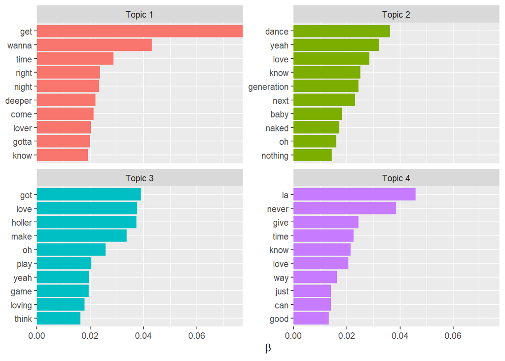

```r
word_topics %>%
  group_by(topic) %>%
  slice_max(beta, n = 10) %>%
  ungroup() %>%
  mutate(topic = paste("Topic", topic)) %>%
  ggplot(aes(beta, reorder_within(term, beta, topic), fill = topic)) +
  geom_col(show.legend = FALSE) +
  facet_wrap(vars(topic), scales = "free_y") +
  scale_x_continuous(expand = c(0, 0)) +
  scale_y_reordered() +
  labs(x = expression(beta), y = NULL)
```

What about the other matrix? We also need to pass in the document_names.

```r
song_topics <- tidy(topic_model,
  matrix = "gamma",
  document_names = rownames(lyrics_sparse)
)
song_topics
```

```
## # A tibble: 124 × 3
##    document                   topic    gamma
##    <chr>                      <int>    <dbl>
##  1 2 Become 1                     1 0.370
##  2 Denying                        1 0.00165
##  3 Do It                          1 0.994
##  4 Get Down With Me               1 0.479
##  5 Goodbye                        1 0.000666
##  6 Holler                         1 0.00168
##  7 If U Can't Dance               1 0.000879
##  8 If You Wanna Have Some Fun     1 0.954
##  9 Last Time Lover                1 0.997
## 10 Let Love Lead the Way          1 0.00149
## # … with 114 more rows
```

Remember that each document (song) was modeled as a mixture of topics. How did that turn out?

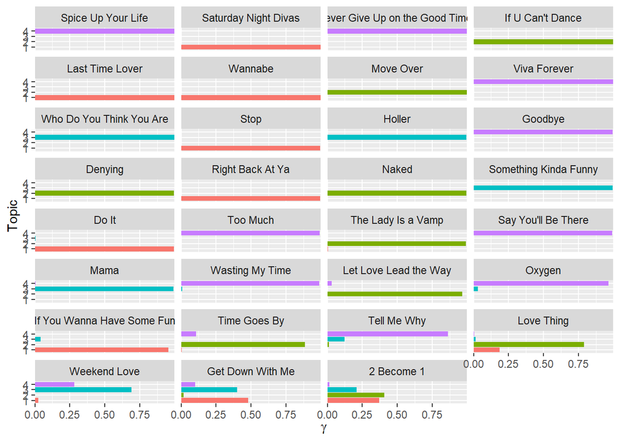

```r
song_topics %>%
  mutate(
    song_name = fct_reorder(document, gamma),
    topic = factor(topic)
  ) %>%
  ggplot(aes(gamma, topic, fill = topic)) +
  geom_col(show.legend = FALSE) +
  facet_wrap(vars(song_name), ncol = 4) +
  scale_x_continuous(expand = c(0, 0)) +
  labs(x = expression(gamma), y = "Topic")
```

The songs near the top of this plot are mostly one topic, while the songs near the bottom are more a mix.

There is a TON more you can do with topic models. For example, we can take the trained topic model and, using some supplementary metadata on our documents, estimate regressions for the proportion of each document about a topic with the metadata as the predictors. For example, let’s estimate regressions for our four topics with the album name as the predictor. This asks the question, “Do the topics in Spice Girls songs change across albums?”

```r
effects <-
  estimateEffect(
    1:4 ~ album_name,
    topic_model,
    tidy_lyrics %>% distinct(song_name, album_name) %>% arrange(song_name)
  )

summary(effects)
```

```
##
## Call:
## estimateEffect(formula = 1:4 ~ album_name, stmobj = topic_model,
##     metadata = tidy_lyrics %>% distinct(song_name, album_name) %>%
##         arrange(song_name))
##
##
## Topic 1:
##
## Coefficients:
##                      Estimate Std. Error t value Pr(>|t|)
## (Intercept)           0.21970    0.13072   1.681    0.104
## album_nameSpice       0.04679    0.18936   0.247    0.807
## album_nameSpiceworld  0.07222    0.18657   0.387    0.702
##
##
## Topic 2:
##
## Coefficients:
##                      Estimate Std. Error t value Pr(>|t|)
## (Intercept)            0.1574     0.1321   1.191    0.244
## album_nameSpice        0.1510     0.1912   0.789    0.436
## album_nameSpiceworld   0.1374     0.1857   0.740    0.466
##
##
## Topic 3:
##
## Coefficients:
##                      Estimate Std. Error t value Pr(>|t|)
## (Intercept)           0.23183    0.11143   2.081   0.0467 *
## album_nameSpice       0.08604    0.15806   0.544   0.5905
## album_nameSpiceworld -0.21939    0.15581  -1.408   0.1701
## ---
## Signif. codes:  0 '***' 0.001 '**' 0.01 '*' 0.05 '.' 0.1 ' ' 1
##
##
## Topic 4:
##
## Coefficients:
##                       Estimate Std. Error t value Pr(>|t|)
## (Intercept)           0.391290   0.138792   2.819  0.00874 **
## album_nameSpice      -0.281995   0.196504  -1.435  0.16235
## album_nameSpiceworld  0.007429   0.192449   0.039  0.96948
## ---
## Signif. codes:  0 '***' 0.001 '**' 0.01 '*' 0.05 '.' 0.1 ' ' 1
```

```r
tidy(effects)
```

```
## # A tibble: 12 × 6
##    topic term                 estimate std.error statistic p.value
##    <int> <chr>                   <dbl>     <dbl>     <dbl>   <dbl>
##  1     1 (Intercept)           0.218       0.131    1.66   0.107
##  2     1 album_nameSpice       0.0469      0.189    0.248  0.806
##  3     1 album_nameSpiceworld  0.0729      0.189    0.387  0.702
##  4     2 (Intercept)           0.158       0.132    1.20   0.241
##  5     2 album_nameSpice       0.150       0.190    0.791  0.435
##  6     2 album_nameSpiceworld  0.139       0.186    0.748  0.461
##  7     3 (Intercept)           0.232       0.110    2.10   0.0445
##  8     3 album_nameSpice       0.0834      0.156    0.533  0.598
##  9     3 album_nameSpiceworld -0.221       0.154   -1.43   0.163
## 10     4 (Intercept)           0.390       0.138    2.82   0.00871
## 11     4 album_nameSpice      -0.282       0.191   -1.48   0.151
## 12     4 album_nameSpiceworld  0.00951     0.192    0.0496 0.961
```

Looks like there is no statistical evidence of change in the lyrical content of the Spice Girls songs across these three albums!